# Modeling and prediction for movies

## Setup

Load required packages and data.

```r
library(ggplot2)
library(dplyr)
library(statsr)
library(GGally)
```

```r
load("movies.Rdata")
```

## 1. Data

The data contains details about 651 movies that were made between 1970 and 2014. The details involve theatrical release year, director, scores and ratings from critics and moviegoers, actors and actresses etc. There are a total of 32 variables which are given below.

```r
names(movies)
```

```
##  [1] "title"            "title_type"       "genre"            "runtime"
##  [5] "mpaa_rating"      "studio"           "thtr_rel_year"    "thtr_rel_month"
##  [9] "thtr_rel_day"     "dvd_rel_year"     "dvd_rel_month"    "dvd_rel_day"
## [13] "imdb_rating"      "imdb_num_votes"   "critics_rating"   "critics_score"
## [17] "audience_rating"  "audience_score"   "best_pic_nom"     "best_pic_win"
## [21] "best_actor_win"   "best_actress_win" "best_dir_win"     "top200_box"
## [25] "director"         "actor1"           "actor2"           "actor3"
## [29] "actor4"           "actor5"           "imdb_url"         "rt_url"
```

### 1.1 Data collection and scope

The data has been randomly sampled from IMDB and rotten tomatoes. Therefore, the results are **generalizable**. The total number of 651 movies is good enough.

There is no random assignment because this is an observation data set. Therefore, **No causal** relationships can be inferred. Only associations and correlations can be inferred.

## 2. Research question

Is there an association between the variables run-time, critics’ score, critics’ rating, title type, genre, and whether a main actor or actress in the movie has won an academy award previously and the ‘Audience score’ of that movie.

**Variables:**  
Response variable: audience_score  
Explanatory variables: runtime, critics_score, critics_rating, title_type, genre, best_actor_win, best_actress_win

**Rationale for the question:** As an avid moviegoer, I am interested in finding out which factors determine the rating of a movie given by the audience. Movies with higher run-times might be boring to the viewers. Critical score and rating can bias the viewers’ assessment of the movie. Similar biases can be caused by big movie personalities such as previous Oscars winners. On the other hand, type of the movie can also determine the audience score. For example, people do not usually like documentaries. A similar argument can be made about the genre. Most people might prefer action movies.

## 3. Explanatory data analysis

The variables *runtime*, *audience_score*, and *critics_score* are numerical variables. **Summary statistics** on these variables are as follows.

```r
summary(movies$runtime)
```

```
##    Min. 1st Qu.  Median    Mean 3rd Qu.    Max.    NA's
##    39.0    92.0   103.0   105.8   115.8   267.0       1
```

Minimum and maximum of *runtime* are 39 to 267 minutes with an average of 105.8 minutes. There is one *NA* value.

```r
summary(movies$audience_score)
```

```
##    Min. 1st Qu.  Median    Mean 3rd Qu.    Max.
##   11.00   46.00   65.00   62.36   80.00   97.00
```

```r
summary(movies$critics_score)
```

```
##    Min. 1st Qu.  Median    Mean 3rd Qu.    Max.
##    1.00   33.00   61.00   57.69   83.00  100.00
```

The scores of audience and critics apparently run from 1 to 100. The average *audience_score* is 62.36, whereas that of *critics_score* is 57.69.

The variables *critics_rating*, *title_type*, *best_actor_win*, and *best_actress_win* are categorical variables. **Summary statistics** of them are given below.

```r
summary(movies$critics_rating)
```

```
## Certified Fresh           Fresh          Rotten
##             135             209             307
```

```r
summary(movies$title_type)
```

```
##  Documentary Feature Film     TV Movie
##           55          591            5
```

Majority (591) are feature movies while 55 are documentaries. There are also 5 TV movies.

```r
summary(movies$best_actor_win)
```

```
##  no yes
## 558  93
```

```r
summary(movies$best_actress_win)
```

```
##  no yes
## 579  72
```

In both actors and actress variables, most have not previously won any academy awards.

Before continuing further, let us extract the relevant data into a new data frame. Also let us remove *NA* values.

```r
# Remove NA's.
mdata <- movies %>%
  select(audience_score, runtime, critics_score, critics_rating, title_type,
         best_actor_win, best_actress_win, genre) %>%
  filter(!is.na(runtime))
```

Let us look at the distribution of run-times of movies.

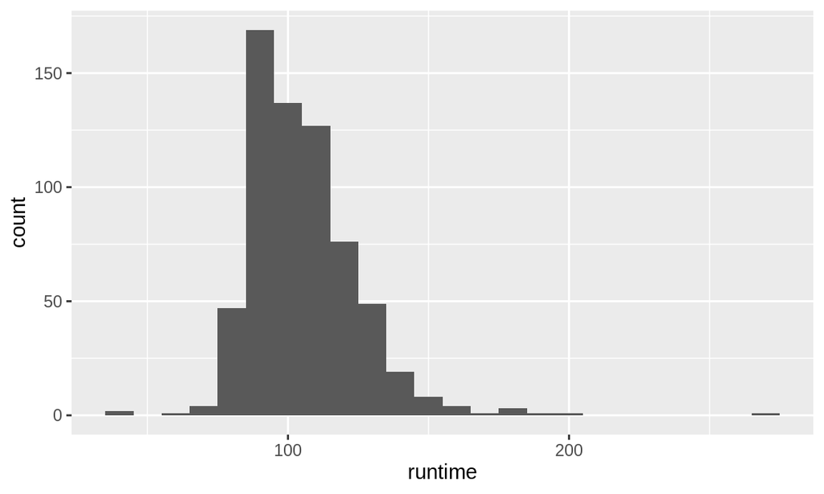

```r
ggplot(data = mdata, aes(x = runtime)) + geom_histogram(binwidth = 10)
```

Distribution appears to be nearly normal and right skewed.

Similarly, histograms of audience and critics’ score are given below.

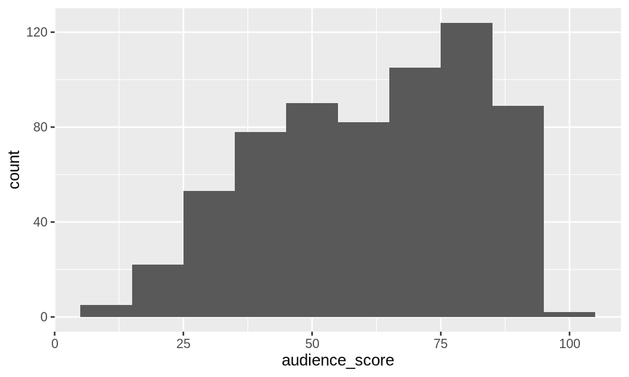

```r
ggplot(data = mdata, aes(x = audience_score)) + geom_histogram(binwidth = 10)
```

Audience score are not normal. The scores are left skewed.

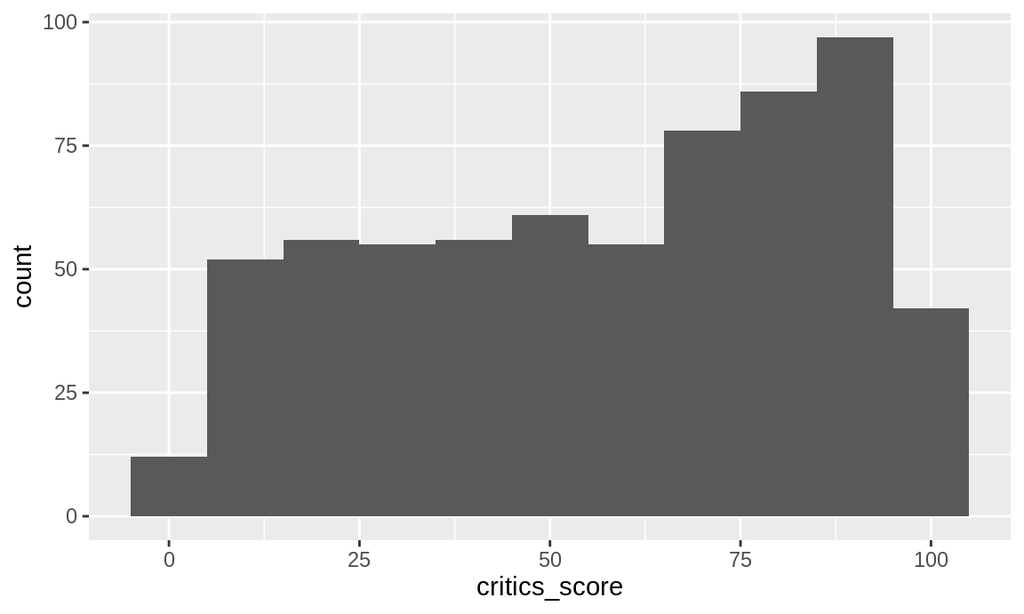

```r
ggplot(data = mdata, aes(x = critics_score)) + geom_histogram(binwidth = 10)
```

Similarly, critical scores are not normal and they appear to be somewhat left skewed.

### 3.1 Possible predictors of *audience_score*

Let us see whether there is an association between audience and critical scores.

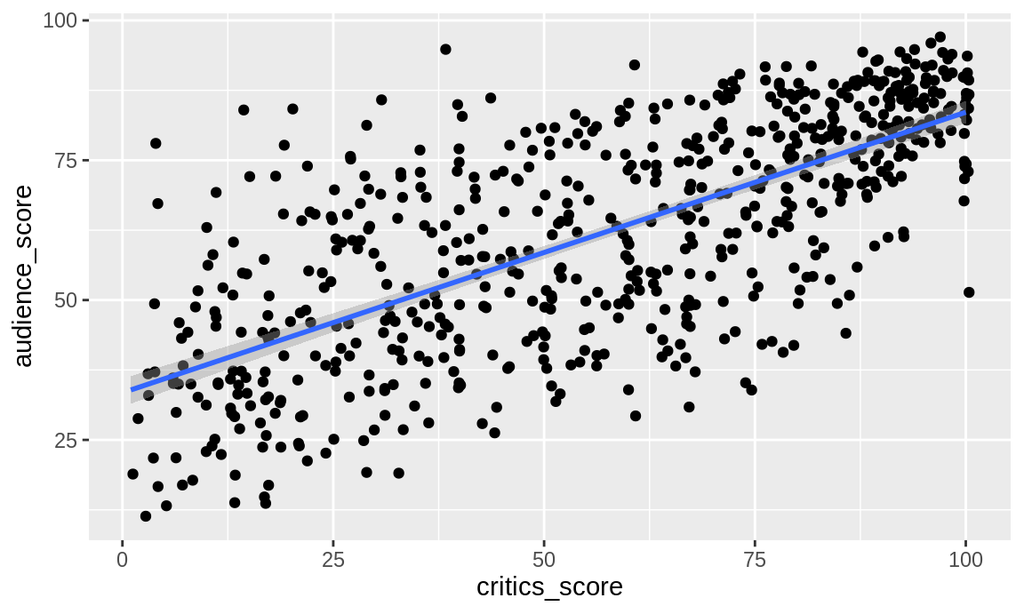

```r
ggplot(data = mdata, aes(x = critics_score, y = audience_score)) +
  geom_jitter() +
  geom_smooth(method = 'lm')
```

From a superficial look, it appears that there is an association between the two variables. Therefore, *critics_score* might be a predictor of *audience_score*.

Let us now investigate whether a similar trend can be seen for variables *audience_score* and *runtime*.

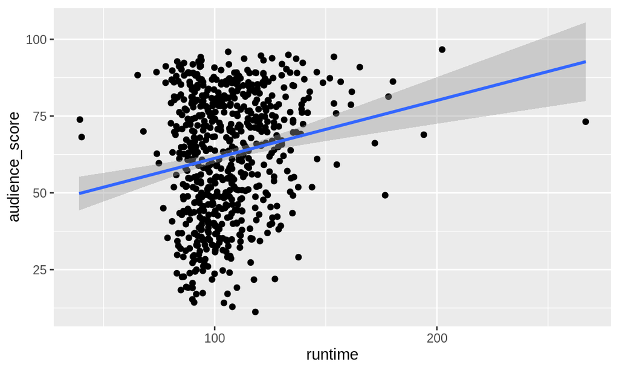

```r
ggplot(data = mdata, aes(x = runtime, y = audience_score)) +
  geom_jitter() +
  geom_smooth(method = 'lm')
```

It is appears that there is a negligible association between the two variables. It appears that *runtime* is not a good predictor of the variable *audience_score*. However, a better calculation based method would be required to come to a complete understanding.

Let us create a side by side boxplot between the *audience_score* and *title_type* variable.

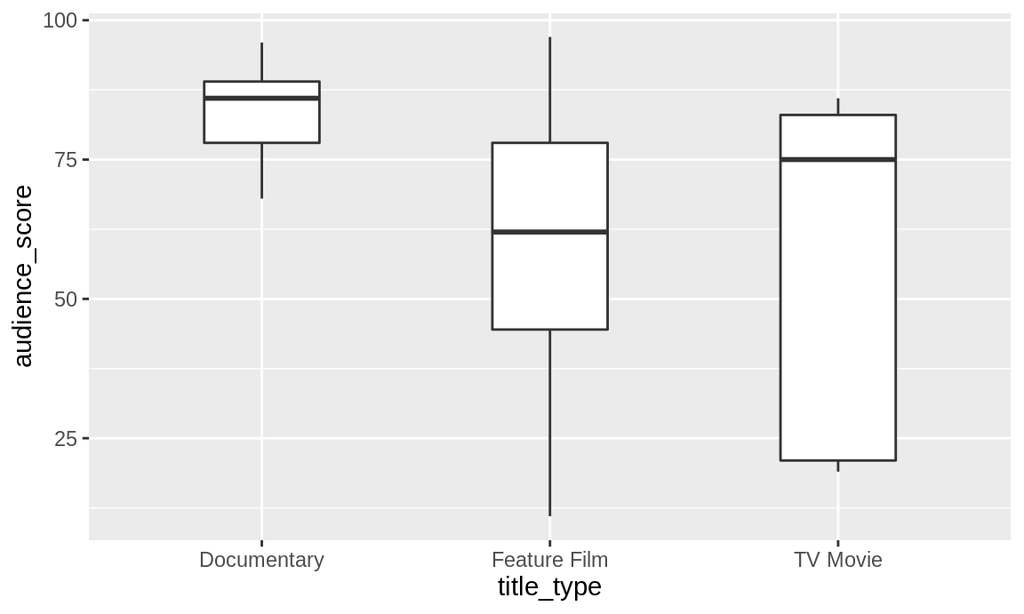

```r
ggplot(data = mdata, aes(x = title_type, y = audience_score)) +
  geom_boxplot(width=0.4)
```

It appears that documentaries have received high audience scores than feature films and TV movies. Whereas documentaries have the lowest IQR, TV movies have the highest. It might be possible that *audience_score* is associated with *title_type* variable.

Similar analyses for the possible relationships between the variables *audience_score* and *best_actor_win* and the variables *audience_score* and *best_actress_win* are given below.

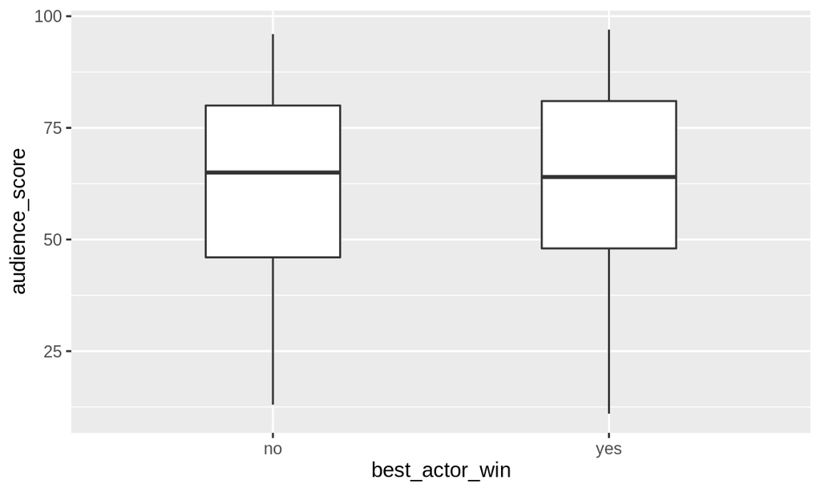

```r
ggplot(data = mdata, aes(x = best_actor_win, y = audience_score)) +
  geom_boxplot(width=0.4)
```

The ranges as well as the IQRs appear to be similar for both levels in the explanatory variable. Therefore, the distribution of *audience_score* variable appears to have no bearing on whether a main actor in a movie had previously won the Oscar award.

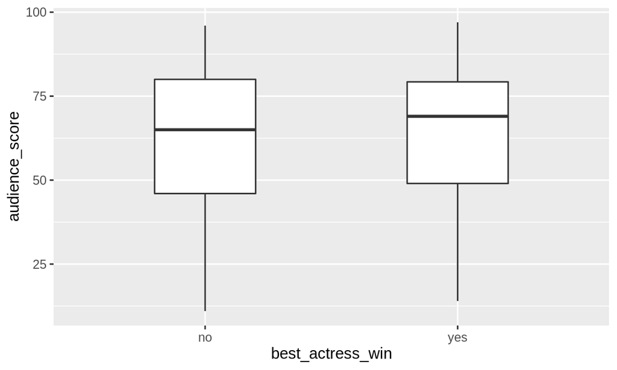

```r
ggplot(data = mdata, aes(x = best_actress_win, y = audience_score)) +
  geom_boxplot(width=0.4)
```

The results of this is similar to that of the previous case. The ranges and IQRs are similar in both levels. It appears both *best_actor_win* and *best_actress_win* are not very important in predicting the *audience_score*. However, a better statistical analysis is required to reach a concrete answer.

Let us now check whether there is an association between the variables *audience_score* and *critics_rating*.

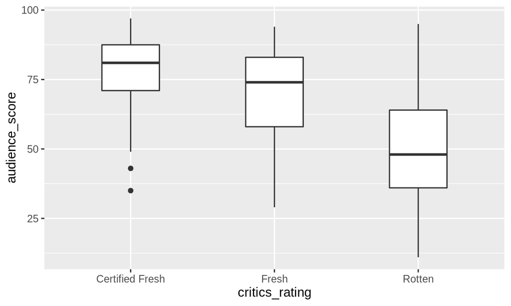

```r
ggplot(data = mdata, aes(x = critics_rating, y = audience_score)) +
  geom_boxplot(width=0.4)
```

The relationship between **audience_score** and the **genre** is examined below.

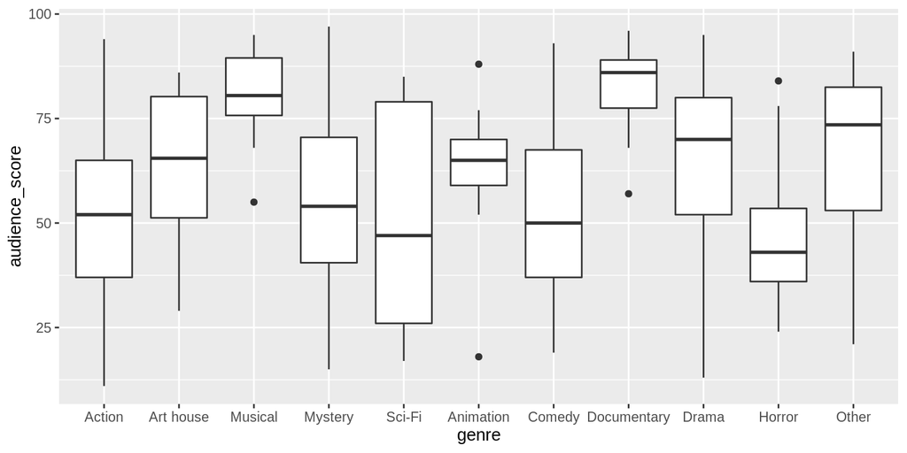

```r
# Let us rename the levels of genre variable so that it is easier to plot.
mdata$genre <- recode_factor(mdata$genre, "Action & Adventure" = "Action",
                             "Art House & International" = "Art house",
                             "Musical & Performing Arts" = "Musical",
                             "Mystery & Suspense" = "Mystery",
                             "Science Fiction & Fantasy" = "Sci-Fi")

ggplot(data = mdata, aes(x = genre, y = audience_score)) +
  geom_boxplot()
```

It is clear that **genere** introduces some variability to **audience_score** variable. The median of **audience_score** depends on the level of the **genre** variable. For instance, musicals and documentaries have median values higher than 75.

## 4. Modeling

### 4.1 Omitting some variables

Some explanatory variables in the data set might be **co-linear** i.e. have strong associations between themselves. Such variables would give rise to a biased model. For example, **critics_score** and **critics_rating** might be strongly associated because the latter is calculated based on the former. Therefore, **critics_rating** should be omitted from the model.

The relationship is given below.

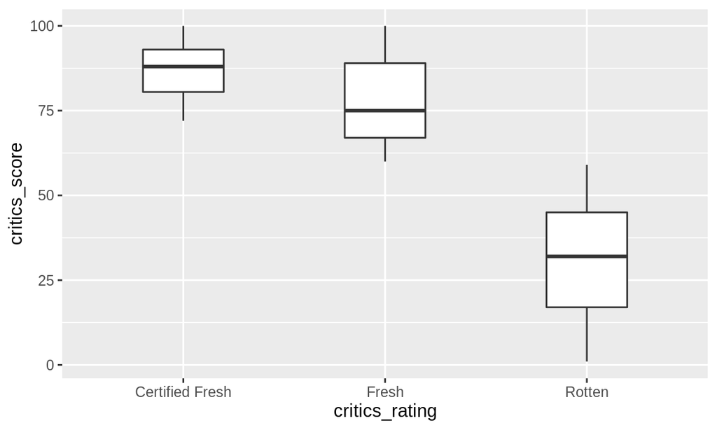

```r
ggplot(data = mdata, aes(x = critics_rating, y = critics_score)) +
  geom_boxplot(width=0.4)
```

It is clear that “Certified Fresh” and “Fresh” ratings correspond to very high **critics_score** values (e.g. median equal to or above 75 in both cases). A “Rotten” rating is observed for low scored movies.

On the other hand, the variables such as **director**, **actor1,2,3,4,5** are useless in the modeling. This is mainly because they have large number of levels and they do not make a statistical sense. Therefore, they were omitted from the model.

### 4.2 Full Model

The preliminary model is given below. The variables were given in the research question section. Variable names are the same used in the data frame.

$$\begin{align}
\widehat{audience\_score} \sim & \ runtime \ + \ critics\_score \ +\ title\_type \ +\\
& \ best\_actor\_win \ +\ best\_actress\_win \ + \ genre
\end{align}$$

### 4.3 Model selection method

Model selection method is backwards elimination based on the adjusted $R^2$ value.

**Rationale:** Backwards elimination works based on a model containing a set of predictor variables. The aim is to remove variables that do not contribute to the prediction power of the model. As we already have a model, this method is suitable. Adjusted $R^2$ is better than the P-value based method, because it is a more reliable indicator and it is not bound by an arbitrary cut off value like in the P-value based methods.

### 4.4 Model selection

The model is given below.

```r
movmod = lm(audience_score ~ runtime + critics_score + title_type + best_actor_win +
              best_actress_win + genre, data = mdata)
summary(movmod)
```

```
##
## Call:
## lm(formula = audience_score ~ runtime + critics_score + title_type +
##     best_actor_win + best_actress_win + genre, data = mdata)
##
## Residuals:
##     Min      1Q  Median      3Q     Max
## -36.587  -9.226   0.320   9.326  41.232
##
## Coefficients:
##                        Estimate Std. Error t value Pr(>|t|)
## (Intercept)            24.16972    6.41696   3.767 0.000181 ***
## runtime                 0.08233    0.03161   2.604 0.009420 **
## critics_score           0.45222    0.02202  20.535  < 2e-16 ***
## title_typeFeature Film  2.47012    5.18279   0.477 0.633810
## title_typeTV Movie     -4.77519    8.18712  -0.583 0.559928
## best_actor_winyes      -1.27174    1.64771  -0.772 0.440507
## best_actress_winyes    -1.36224    1.81960  -0.749 0.454348
## genreArt house          5.69411    4.13242   1.378 0.168718
## genreMusical           10.42103    4.74792   2.195 0.028536 *
## genreMystery           -4.02662    2.55747  -1.574 0.115882
## genreSci-Fi            -6.67729    4.98025  -1.341 0.180481
## genreAnimation          6.20480    5.01416   1.237 0.216377
## genreComedy            -0.30540    2.31565  -0.132 0.895117
## genreDocumentary       11.67476    5.49996   2.123 0.034167 *
## genreDrama              1.98705    1.98467   1.001 0.317113
## genreHorror            -8.27689    3.41421  -2.424 0.015619 *
## genreOther              2.41742    3.96297   0.610 0.542078
## ---
## Signif. codes:  0 '***' 0.001 '**' 0.01 '*' 0.05 '.' 0.1 ' ' 1
##
## Residual standard error: 13.98 on 633 degrees of freedom
## Multiple R-squared:  0.5343, Adjusted R-squared:  0.5225
## F-statistic: 45.39 on 16 and 633 DF,  p-value: < 2.2e-16
```

Only the variables **runtime**, **critics_score**, and **genre** are statistically significant predictors of **audience_score** based on the t test of the full model. However, as we are using adjusted $R^2$ for model selection, we shall continue with all the variables.

#### 4.4.1 Step 1

```r
# Step 1
# Drop: runtime
movmod1 = lm(audience_score ~ critics_score + title_type + best_actor_win +
              best_actress_win + genre, data = mdata)
summary(movmod1)$adj.r.squared
```

```
## [1] 0.5181809
```

```r
# Drop: critics_score
movmod2 = lm(audience_score ~ runtime + title_type + best_actor_win +
              best_actress_win + genre, data = mdata)
summary(movmod2)$adj.r.squared
```

```
## [1] 0.2057072
```

```r
# Drop: title_type
movmod3 = lm(audience_score ~ runtime + critics_score + best_actor_win +
              best_actress_win + genre, data = mdata)
summary(movmod3)$adj.r.squared
```

```
## [1] 0.5228868
```

```r
# Drop: best_actor_win
movmod4 = lm(audience_score ~ runtime + critics_score + title_type +
              best_actress_win + genre, data = mdata)
summary(movmod4)$adj.r.squared
```

```
## [1] 0.5228404
```

```r
# Drop: best_actress_win
movmod5 = lm(audience_score ~ runtime + critics_score + title_type + best_actor_win +
              genre, data = mdata)
summary(movmod5)$adj.r.squared
```

```
## [1] 0.5228669
```

```r
# Drop: genre
movmod6 = lm(audience_score ~ runtime + critics_score + title_type + best_actor_win +
              best_actress_win + genre, data = mdata)
summary(movmod6)$adj.r.squared
```

```
## [1] 0.5225359
```

The highest adjusted $R^2$ = 0.5228868 occurred when we dropped the variable **title_type**. Therefore, the new model is given below.

$$\begin{align}
\widehat{audience\_score} \sim & \ runtime \ + \ critics\_score \ +\ best\_actor\_win \ +\ best\_actress\_win \ + \ genre
\end{align}$$

Let us restart the process.

#### 4.4.2 Step 2

```r
# Step 2: starting point
movmod = lm(audience_score ~ runtime + critics_score + best_actor_win +
              best_actress_win + genre, data = mdata)
summary(movmod)$adj.r.squared
```

```
## [1] 0.5228868
```

```r
# Drop: runtime
movmod1 = lm(audience_score ~ critics_score + best_actor_win +
              best_actress_win + genre, data = mdata)
summary(movmod1)$adj.r.squared
```

```
## [1] 0.5183336
```

```r
# Drop: critics_score
movmod2 = lm(audience_score ~ runtime + best_actor_win +
              best_actress_win + genre, data = mdata)
summary(movmod2)$adj.r.squared
```

```
## [1] 0.2020536
```

```r
# Drop: best_actor_win
movmod3 = lm(audience_score ~ runtime + critics_score +
              best_actress_win + genre, data = mdata)
summary(movmod3)$adj.r.squared
```

```
## [1] 0.5232491
```

```r
# Drop: best_actress_win
movmod4 = lm(audience_score ~ runtime + critics_score + best_actor_win +
              genre, data = mdata)
summary(movmod4)$adj.r.squared
```

```
## [1] 0.5231884
```

```r
# Drop: genre
movmod5 = lm(audience_score ~ runtime + critics_score + best_actor_win +
              best_actress_win, data = mdata)
summary(movmod5)$adj.r.squared
```

```
## [1] 0.4980719
```

The highest adjusted $R^2$ = 0.5232491 occurred when we dropped the variable **best_actor_win**. The new model is given as follows.

$$\begin{align}
\widehat{audience\_score} \sim & \ runtime \ + \ critics\_score \ +\ best\_actress\_win \ + \ genre
\end{align}$$

Let us restart the process.

#### 4.4.3 Step 3

```r
# Step 3: starting point
movmod = lm(audience_score ~ runtime + critics_score +
              best_actress_win + genre, data = mdata)
summary(movmod)$adj.r.squared
```

```
## [1] 0.5232491
```

```r
# Drop: runtime
movmod1 = lm(audience_score ~ critics_score +
              best_actress_win + genre, data = mdata)
summary(movmod1)$adj.r.squared
```

```
## [1] 0.519069
```

```r
# Drop: critics_score
movmod2 = lm(audience_score ~ runtime +
              best_actress_win + genre, data = mdata)
summary(movmod2)$adj.r.squared
```

```
## [1] 0.2030731
```

```r
# Drop: best_actress_win
movmod3 = lm(audience_score ~ runtime + critics_score +
              genre, data = mdata)
summary(movmod3)$adj.r.squared
```

```
## [1] 0.5234885
```

```r
# Drop: genre
movmod4 = lm(audience_score ~ runtime + critics_score +
              best_actress_win, data = mdata)
summary(movmod4)$adj.r.squared
```

```
## [1] 0.4980276
```

The highest adjusted $R^2$ = 0.5234885 occurred when we dropped the variable **best_actress_win**. The new model is given as follows.

$$\begin{align}
\widehat{audience\_score} \sim & \ runtime \ + \ critics\_score \ +\ genre
\end{align}$$

Let us restart the process.

#### 4.4.4 Step 4

```r
# Step 4: starting point
movmod = lm(audience_score ~ runtime + critics_score +
              genre, data = mdata)
summary(movmod)$adj.r.squared
```

```
## [1] 0.5234885
```

```r
# Drop: runtime
movmod1 = lm(audience_score ~ critics_score + genre, data = mdata)
summary(movmod1)$adj.r.squared
```

```
## [1] 0.5197097
```

```r
# Drop: critics_score
movmod2 = lm(audience_score ~ runtime + genre, data = mdata)
summary(movmod2)$adj.r.squared
```

```
## [1] 0.2042889
```

```r
# Drop: genre
movmod3 = lm(audience_score ~ runtime + critics_score, data = mdata)
summary(movmod3)$adj.r.squared
```

```
## [1] 0.4979388
```

The highest adjusted $R^2$ = 0.5234885 is the same highest value recorded in the step 3 i.e. there is not increase in adjusted $R^2$ value in the current step. Therefore, we have come to the final model.

### 4.5 Final model and diagnostics

The details of the final model are given below.

```r
summary(movmod)
```

```
##
## Call:
## lm(formula = audience_score ~ runtime + critics_score + genre,
##     data = mdata)
##
## Residuals:
##     Min      1Q  Median      3Q     Max
## -36.151  -9.586   0.525   9.568  41.424
##
## Coefficients:
##                  Estimate Std. Error t value Pr(>|t|)
## (Intercept)      27.37145    3.59290   7.618 9.35e-14 ***
## runtime           0.07482    0.03040   2.462 0.014097 *
## critics_score     0.45007    0.02175  20.697  < 2e-16 ***
## genreArt house    5.74324    4.12223   1.393 0.164035
## genreMusical      9.77902    4.45744   2.194 0.028606 *
## genreMystery     -4.38861    2.53277  -1.733 0.083628 .
## genreSci-Fi      -6.54296    4.97258  -1.316 0.188711
## genreAnimation    5.94345    4.99993   1.189 0.234998
## genreComedy      -0.53569    2.29935  -0.233 0.815856
## genreDocumentary  9.45211    2.81096   3.363 0.000818 ***
## genreDrama        1.68250    1.96516   0.856 0.392229
## genreHorror      -8.22215    3.40868  -2.412 0.016142 *
## genreOther        1.79864    3.93336   0.457 0.647627
## ---
## Signif. codes:  0 '***' 0.001 '**' 0.01 '*' 0.05 '.' 0.1 ' ' 1
##
## Residual standard error: 13.97 on 637 degrees of freedom
## Multiple R-squared:  0.5323, Adjusted R-squared:  0.5235
## F-statistic: 60.42 on 12 and 637 DF,  p-value: < 2.2e-16
```

$$\begin{align}
\widehat{audience\_score} = & \ 27.37 + 0.075 \times runtime \ + \ 0.45 \times critics\_score \ +\ 5.74 \times \text{genre:Art house} \ + \\
& \ 9.78 \times \text{genre:Musical} - 4.39 \times \text{genre:Mystery} -6.54 \times \text{genre:Sci-Fi} \ + \\
& \ 5.94 \times \text{genre:Animation} - 0.54 \times \text{genre:Comedy} + 9.45 \times \text{genre:Documentary} \ + \\
& \ 1.68 \times \text{genre:Drama} - 8.22 \times \text{genre:Horror} + 1.80 \times \text{genre:Other}
\end{align}$$

The reference level of **genre** is “Action”.

#### 4.5.1 Diagnostics

1. Normality of residuals with mean 0

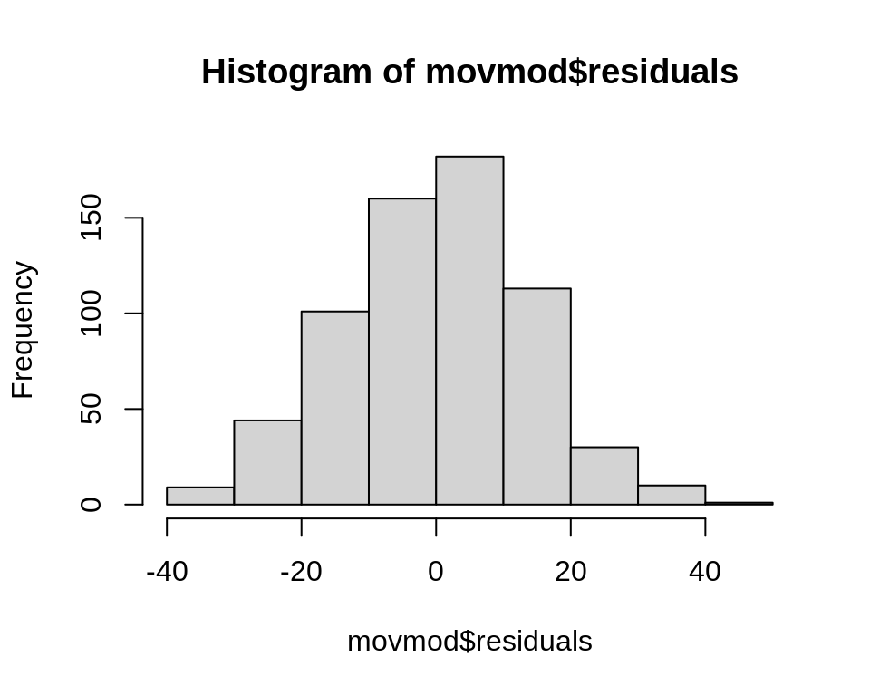

```r
hist(movmod$residuals)
```

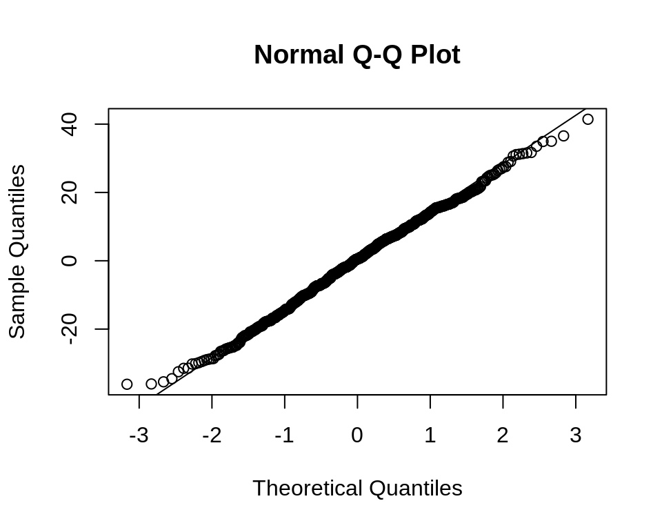

```r
qqnorm(movmod$residuals); qqline(movmod$residuals)
```

```r
mean(movmod$residuals)
```

```
## [1] 1.73882e-16
```

We can clearly see that the residuals are distributed **nearly normally** around an approximate mean of 0 $( \approx 1.74 \times 10^{-16} )$.

2. Constant variability of residuals

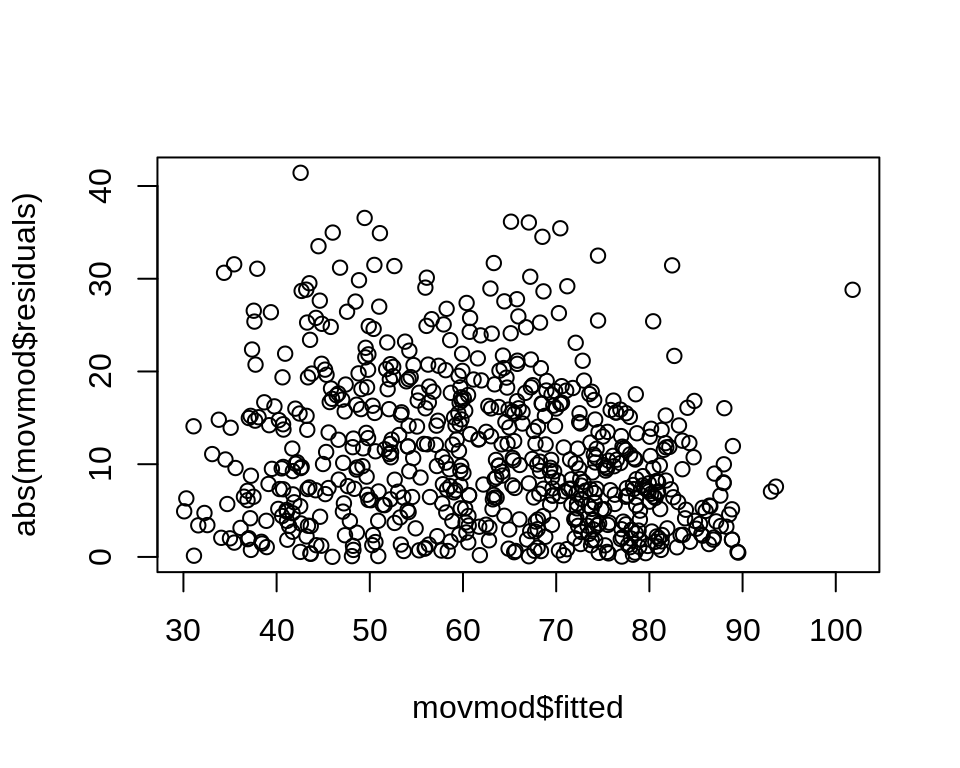

```r
plot(abs(movmod$residuals) ~ movmod$fitted)
```

The absolute values of the residuals are distributed randomly.

3. Independence of residuals

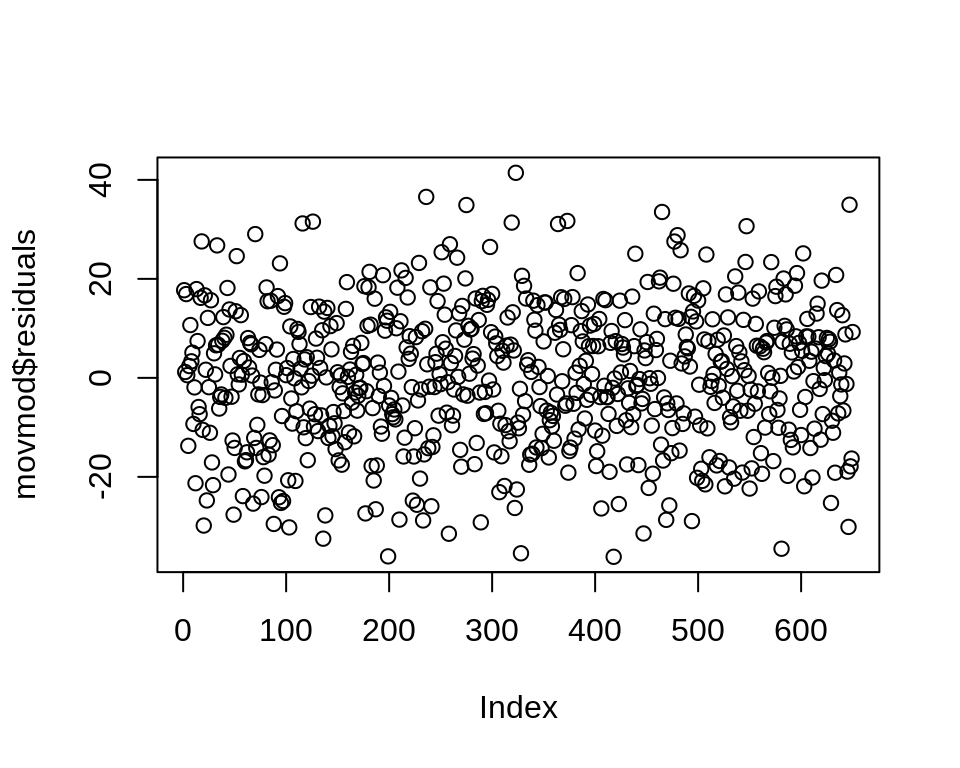

```r
plot(movmod$residuals)
```

The residuals are scattered randomly. Therefore, we can conclude that there is no time series structure in the data i.e. the observations are independent of each other and the order of data collection does not have any impact on the model.

4. Linearity between residuals and numerical variables

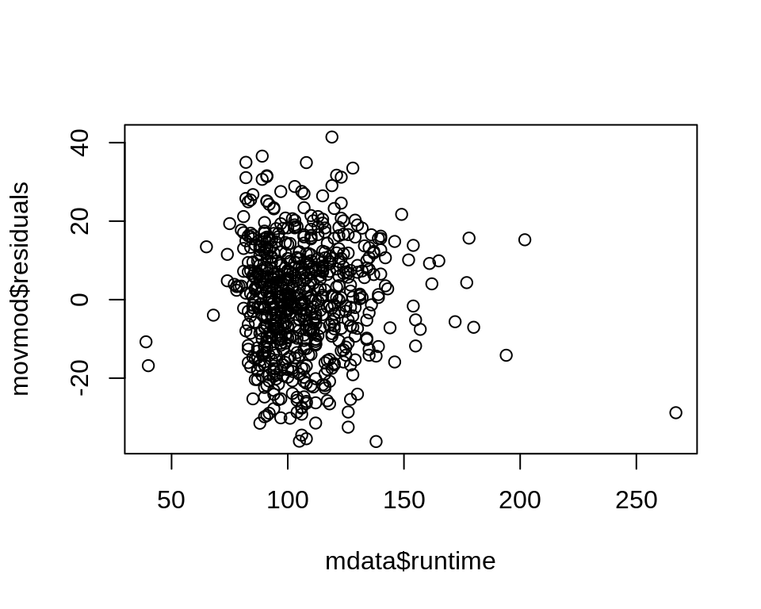

```r
plot(movmod$residuals ~ mdata$runtime)
```

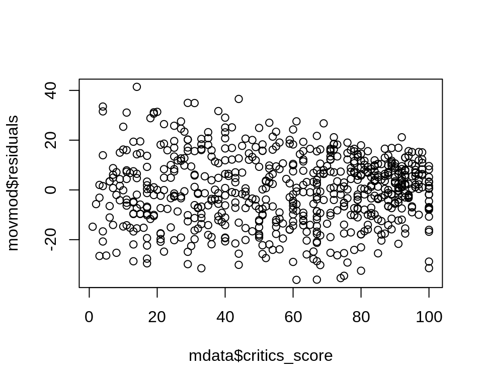

```r
plot(movmod$residuals ~ mdata$critics_score)
```

The numerical variables are **runtime** and **critics_score**. With respect to both of them, the residuals are scattered randomsly around 0. Therefore, we can conclude that there is a linear relationship between the predicted value and these variables.

### 4.6 Interpretation

Interpretation of coefficients are presented here.

[output not shown]

## 5. Prediction

The chosen movies from the year 2016 is “Nerve”. The data came from the link: https://www.rottentomatoes.com/m/nerve_2016. The details are as follows.

| Parameter | Value |
| --- | --- |
| Audience score | 66% |
| Run-time | 96 minutes |
| Critical Score | 66% |
| Genre | Action |

Let us create a data frame for this data.

```r
nerve <- data.frame(runtime = 96, critics_score = 66, genre = "Action")
```

Prediction for the movie.

```r
predict(movmod, nerve)
```

```
##        1
## 64.25884
```

**Interpretation of the prediction:** The model predicts, on average, a movie with 66% critical score, of “Action” genre, with a run-time of 96 minutes would have an audience score of 64.26%. This values is very close to the real value given in the above reference i.e. 66%.

The prediction interval for the movie at 95% confidence is given below.

```r
predict(movmod, nerve, interval = "prediction", level = 0.95)
```

```
##        fit      lwr     upr
## 1 64.25884 36.59337 91.9243
```

**Interpretation of the prediction interval:** The model predicts, on average, with a 95% confidence, that an “Action” movie of run-time of 96 minutes having a critical score of 66% would have an audience score between 36.59% and 91.92%. The real value (66%) is encapsulated by the predicted interval i.e. the prediction and the real value agree with the interval.

## 6. Conclusion

Based on the diagnostics, the model is very suitable for the task. The value of the **audience_score** is strongly associated with the variables **runtime**, **genre**, and **critics_score**. The model provides agreeable predictions based on its training data set. In the test case, the deviation between the real value and the prediction was about 2%.

**Shortcomings:**  
One of the issues with this type of analysis is that most movies belong to multiple genres. For instance, the movie “Nerve” also belongs to the Mystery genre according to the source. In such cases, the audience score might be erroneous because different people watch different movies based on their personal preferences and this might impact the score they would attach to the movie.

Another important fact is that the training data set (provided in “movies.RData”) might not be a representative set. For example, there are more “Feature films” than documentaries etc. The same is true for other title types and genres. This could, in theory, give rise to a biased model.

**Suggestions:**  
Use a larger, fairer sample from all the movies created in the Hollywood for developing a better model.